# hito1

```python
import pandas as pd
import seaborn as sns
import matplotlib.pyplot as plt
```

## 1. Carga y analisis exploratorio de los datos

Cargamos el `csv` que nos ha proporcionado `Apache Nifi` tras unir los datos de ambas bases de datos `Postgres` y `Mongo`.

```python
df = pd.read_csv("btc_simulacion.csv", parse_dates=["timestamp"])
```

Mostramos las 5 primeras filas del dataset

```python
df.head()
```

|  | timestamp | precio_btc | cambio | clima | tendencia_largo_plazo | sentimiento_detectado | max_historico | relacion_con_max | dias_en_euforia | dias_rebote_fuerte | factor_tipos_interes | factor_inflacion | factor_adopcion_institucional | factor_noticias | factor_regulacion | factor_halving | factor_seguridad_tecnologica | factor_oferta_demanda | factor_sentimiento_mercado |
| --- | --- | --- | --- | --- | --- | --- | --- | --- | --- | --- | --- | --- | --- | --- | --- | --- | --- | --- | --- |
| 0 | 2009-01-01 | 30080 | 80 | 0.50 | 4 | 0.0 | 30080 | 1.0000 | 0 | 0 | -1.00 | 0.0 | 0.0 | 0.0 | 0.00 | 0.00 | 0.0 | 0.0 | 1.00 |
| 1 | 2009-01-02 | 29552 | -528 | -1.86 | 4 | 0.0 | 30080 | 0.9824 | 0 | 0 | -0.93 | 0.0 | 0.0 | 0.0 | 0.00 | 1.00 | 0.0 | 0.0 | -1.00 |
| 2 | 2009-01-03 | 29986 | 434 | 2.00 | 3 | 0.0 | 30080 | 0.9969 | 0 | 0 | 1.00 | 0.0 | 0.0 | 0.0 | 0.00 | 0.93 | 0.0 | 0.0 | -0.93 |
| 3 | 2009-01-04 | 30827 | 841 | 4.86 | 2 | 0.0 | 30827 | 1.0000 | 0 | 0 | 0.93 | 0.0 | 0.0 | 0.0 | 1.00 | 0.86 | 0.0 | 0.0 | -0.86 |
| 4 | 2009-01-05 | 31168 | 341 | 4.79 | 4 | 0.0 | 31168 | 1.0000 | 0 | 0 | 1.00 | 0.0 | 0.0 | 0.0 | 0.93 | 0.79 | 0.0 | 0.0 | -0.79 |

Con esto onfirmamos que el `csv` se ha guardado perfectamente.

### 1.1. Columnas del dataset

Informacion general de cada columna.

```python
df.info()
```

```
<class 'pandas.core.frame.DataFrame'>
RangeIndex: 8035 entries, 0 to 8034
Data columns (total 19 columns):
 #   Column                         Non-Null Count  Dtype
---  ------                         --------------  -----
 0   timestamp                      8035 non-null   datetime64[ns]
 1   precio_btc                     8035 non-null   int64
 2   cambio                         8035 non-null   int64
 3   clima                          8035 non-null   float64
 4   tendencia_largo_plazo          8035 non-null   int64
 5   sentimiento_detectado          8035 non-null   float64
 6   max_historico                  8035 non-null   int64
 7   relacion_con_max               8035 non-null   float64
 8   dias_en_euforia                8035 non-null   int64
 9   dias_rebote_fuerte             8035 non-null   int64
 10  factor_tipos_interes           8035 non-null   float64
 11  factor_inflacion               8035 non-null   float64
 12  factor_adopcion_institucional  8035 non-null   float64
 13  factor_noticias                8035 non-null   float64
 14  factor_regulacion              8035 non-null   float64
 15  factor_halving                 8035 non-null   float64
 16  factor_seguridad_tecnologica   8035 non-null   float64
 17  factor_oferta_demanda          8035 non-null   float64
 18  factor_sentimiento_mercado     8035 non-null   float64
dtypes: datetime64[ns](1), float64(12), int64(6)
memory usage: 1.2 MB
```

Vemos que nuestro dataset consta de `19 columnas` y `8035 filas` que corresponden a 8035 dias simulados.

De las 19 columnas se nos ofrece el siguiente reparto de `tipos de datos`:

| Tipo de dato | Cantidad |
| --- | --- |
| datetime | 1 |
| float64 | 12 |
| int64 | 6 |

### 1.2. Columnas del csv explicadas

Ahora explicaremos el `significado` de cada columna, para ello vamos a separar entre las `columnas principales` y las `columnas de factores`:

### 1.3. Columnas principales

| Nombre de la columna | Explicacion | Rango de valores |
| --- | --- | --- |
| timestamp | Fecha de la simulacion | YY: 2009 - 2030 |
| precio_btc | Precio del Bitcoin ese dia | Minimo 100 y no tiene un limite maximo |
| cambio | Variacion del precio tomando de referencia el dia anterior | -1048 a 1055 |
| clima | Refleja si el mercado se encuentra en un estado: muy positivo, muy negativo o neutral, decide si el precio sube o baja | -20 a 20 |
| tendencia_largo_plazo | Es una especie de inercia para provocar que a la larga el precio del BTC aumente | 2 a 5 |
| sentimiento_detectado | Simula el FOMO(compro porque sigue subiendo)/FUD(vendo antes de que se hunda) | -1 a 1 |
| max_historico | Precio maximo del BTC hasta ese dia | Igual o mayor a cualquier valor de cualquier dia anterior |
| relacion_con_max | Sirve para saber como de cerca esta el precio actual del BTC de su precio maximo historico | 0 a 1 |
| dias_en_euforia | Dias restantes de un efecto de "euforia" tras haberse dado un maximo historico | 0 a 3 |
| dias rebote fuerte | Dias restantes de efecto rebote tras una bajada de precio | 0 a 5 |

### 1.4. Columna de factores

| Nombre de la columna | Explicacion | Ejemplo | Rango de valores |
| --- | --- | --- | --- |
| tipos_intereses | Tipos de interes de bancos centrales | La Fed sube tipos (-1) | -1 a 1 |
| inflacion | Inflacion general | Inflacion sube (-1) | -1 a 1 |
| adopcion_institucional | Intereses de bancos/fondos en BTC | BlackRock anuncia ETF de BTC (+1) | -1 a 1 |
| noticias | Medios de comunicacion | Elon Musk hace un tweet positivo sobre BTC (+1) | -1 a 1 |
| regulacion | Leyes, restricciones... | Prohiben BTC en un pais (-1) | -1 a 1 |
| halving | Eventos de reduccion de recompensa de minado | Se acerca halving (+1) | -1 a 1 |
| seguridad_tecnologica | Confianza en seguridad digital, hacks... | Nueva tecnologia segura (+1) | -1 a 1 |
| oferta_demanda | Fuerzas basicas del mercado | Mucha demanda, poca oferta (+1) | -1 a 1 |
| sentimiento_mercado | Resultado de eventos pasados (FOMO/FUD, rebotes, euforia) | FOMO por subida agresiva (+1) | -1 a 1 |

```python
df.describe()
```

|  | timestamp | precio_btc | cambio | clima | tendencia_largo_plazo | sentimiento_detectado | max_historico | relacion_con_max | dias_en_euforia | dias_rebote_fuerte | factor_tipos_interes | factor_inflacion | factor_adopcion_institucional | factor_noticias | factor_regulacion | factor_halving | factor_seguridad_tecnologica | factor_oferta_demanda | factor_sentimiento_mercado |
| --- | --- | --- | --- | --- | --- | --- | --- | --- | --- | --- | --- | --- | --- | --- | --- | --- | --- | --- | --- |
| count | 8035 | 8035.000000 | 8035.000000 | 8035.000000 | 8035.000000 | 8035.000000 | 8035.000000 | 8035.000000 | 8035.000000 | 8035.000000 | 8035.000000 | 8035.000000 | 8035.000000 | 8035.000000 | 8035.000000 | 8035.000000 | 8035.000000 | 8035.000000 | 8035.000000 |
| mean | 2019-12-31 23:59:59.999999744 | 63270.021531 | 3.707778 | -0.013708 | 3.502676 | 0.014897 | 95900.464468 | 0.667618 | 0.136279 | 0.154947 | 0.011217 | -0.050963 | -0.002819 | -0.013658 | 0.009755 | 0.000835 | 0.035439 | -0.003695 | 0.009391 |
| min | 2009-01-01 00:00:00 | 12322.000000 | -930.000000 | -13.790000 | 2.000000 | -0.300000 | 30080.000000 | 0.127700 | 0.000000 | 0.000000 | -1.000000 | -1.000000 | -1.000000 | -1.000000 | -1.000000 | -1.000000 | -1.000000 | -1.000000 | -1.000000 |
| 25% | 2014-07-02 12:00:00 | 47847.000000 | -349.000000 | -2.960000 | 3.000000 | 0.000000 | 93896.000000 | 0.539150 | 0.000000 | 0.000000 | -0.510000 | -0.650000 | -0.580000 | -0.580000 | -0.510000 | -0.580000 | -0.580000 | -0.580000 | -0.300000 |
| 50% | 2020-01-01 00:00:00 | 64103.000000 | -7.000000 | -0.050000 | 4.000000 | 0.000000 | 96514.000000 | 0.658600 | 0.000000 | 0.000000 | 0.000000 | 0.000000 | 0.000000 | 0.000000 | 0.000000 | 0.000000 | 0.000000 | 0.000000 | 0.000000 |
| 75% | 2025-07-01 12:00:00 | 76150.000000 | 353.000000 | 2.950000 | 4.000000 | 0.000000 | 96514.000000 | 0.829100 | 0.000000 | 0.000000 | 0.580000 | 0.510000 | 0.580000 | 0.510000 | 0.580000 | 0.580000 | 0.650000 | 0.580000 | 0.510000 |
| max | 2030-12-31 00:00:00 | 117358.000000 | 945.000000 | 13.590000 | 5.000000 | 1.000000 | 117358.000000 | 1.000000 | 2.000000 | 5.000000 | 1.000000 | 1.000000 | 1.000000 | 1.000000 | 1.000000 | 1.000000 | 1.000000 | 1.000000 | 1.000000 |
| std | NaN | 19897.548828 | 430.444459 | 4.282844 | 1.109215 | 0.160790 | 15651.099210 | 0.197974 | 0.456711 | 0.737698 | 0.617933 | 0.637622 | 0.628777 | 0.617673 | 0.618671 | 0.624275 | 0.633639 | 0.623481 | 0.559742 |

### 1.5. Datos mas destacables

- `precio_btc`: Obeservamos mucha volatilidad, con una desviacion estandar de casi 20.000$
- `cambio`: Observamos que tiene una media cercana a 0 con minimos y maximos cercanos al rango de valores definidos en la simulacion, no se fuerza una tendencia alcista/bajista.
- `clima`: Con minimos en -13, maximos en 13 y una media muy cercana al 0, el mercado oscila en positivo y negativo de manera equilibrada.
- `sentimiento_detectado`: Con una media tan baja (0.01) confirmamos que estos tipos de eventos se activan puntualmente.
- `relacion_con_max`: Al existir minimos de 0.1 sabemos que en la simulacion han existido periodos de tiempo en los que el BTC ha tenido caidas fuertes respecto a su valor maximo.
- `factores(todos)`: Muestran una desviacion tipica cercana al 0.6 en casi todos, hemos logrado simular un entorno cambiante; ademas tienen medias cercanas a cero, tambien hemos conseguido que los factores tiendan a neutralizarse.
- `dias_en_euforia` y `dias_rebote_fuerte`: media baja, 0.13 y 0.15, esto nos hace ver que son eventos raros, pero ocurren.

## 2. Limpieza de datos

### 2.1. Tratado de nulos

```python
print(df.isnull().sum())
```

```
timestamp                        0
precio_btc                       0
cambio                           0
clima                            0
tendencia_largo_plazo            0
sentimiento_detectado            0
max_historico                    0
relacion_con_max                 0
dias_en_euforia                  0
dias_rebote_fuerte               0
factor_tipos_interes             0
factor_inflacion                 0
factor_adopcion_institucional    0
factor_noticias                  0
factor_regulacion                0
factor_halving                   0
factor_seguridad_tecnologica     0
factor_oferta_demanda            0
factor_sentimiento_mercado       0
dtype: int64
```

No tenemos nulos en nuestro dataset.

### 2.2. Tratado de duplicados

```python
df_sin_fechas = df.drop(columns=['timestamp'])
print(f"Filas duplicadas: {df_sin_fechas.duplicated().sum()}")
```

```
Filas duplicadas: 0
```

Incluso eliminando las fechas para intentar hacer una busqueda valida con esta consulta, no hay 2 dias iguales, todos tienen precios y factores distintos.

## 3. Representacion y analisis grafico

### 3.1. Evolucion temporal del precio del BTC

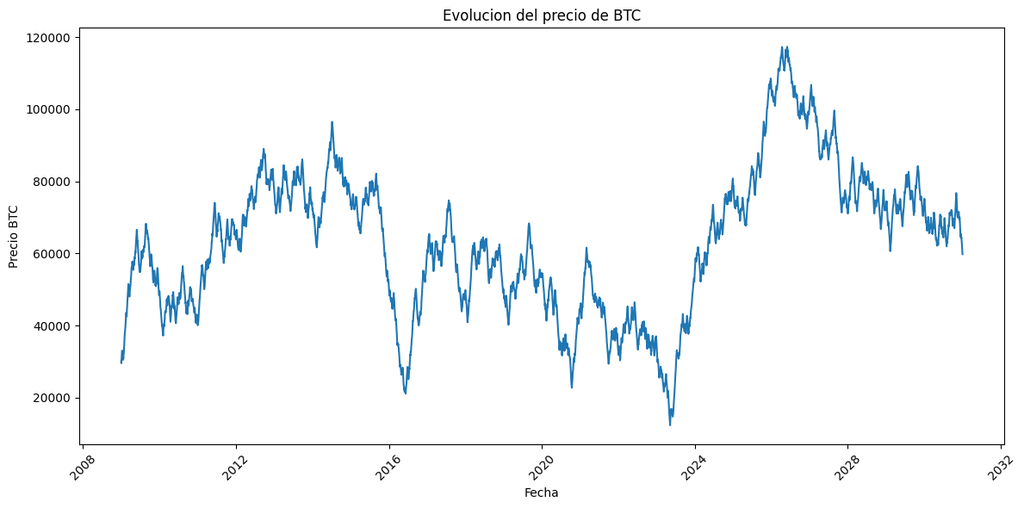

```python
import seaborn as sns
import matplotlib.pyplot as plt

plt.figure(figsize=(12, 6))
sns.lineplot(data=df, x="timestamp", y="precio_btc")
plt.title("Evolucion del precio de BTC")
plt.xlabel("Fecha")
plt.ylabel("Precio BTC")
plt.xticks(rotation=45)
plt.tight_layout()
plt.show()
```

- Ciclos de acumulacion y correccion, incluso con picos marcados alrededor de 2015, 2020 y 2026.
- Hay una fase bajista fuerte sobre el 2022-23 que probablemente activase muchos dias de rebote (`dias_de_rebote_fuerte`) por tener valores tan bajos.
- Despues de esa caida se ve una euforia brutal, que es cuando se consigue el maximo historico por encima de los 115.000$ y luego se corrige.

### 3.2. Distribuicion del cambio diario

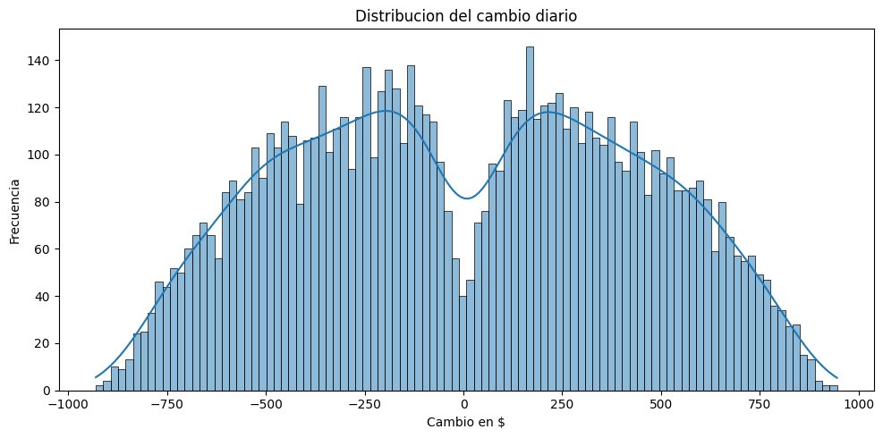

```python
plt.figure(figsize=(10, 5))
sns.histplot(df["cambio"], bins=100, kde=True)
plt.title("Distribucion del cambio diario")
plt.xlabel("Cambio en $")
plt.ylabel("Frecuencia")
plt.tight_layout()
plt.show()
```

- Distribuicion en forma de campana con un hundimiento en el centro (0) probablemente debido a la columna `tendencia_largo_plazo`, haciendo que los cambios de 0 no sean frecuentes.
- Hay un leve sesgo positivo, el pico mas alto esta en la derecha, sguramente tambien lo provoque la `tendencia_largo_plazo`, que empuja el precio ligeramente hacia arriba en promedio.
- Hay simetria, por lo que nuestra simulacion genera subidas y bajas con igual probabilidad y el sesgo lo mete la `tendencia_largo_plazo`.
- Aunque haya una ligera tendencia alcista vemos como la simulacion respeta la idea de un mercado realista, con emociones y rebotes.

### 3.3. Clima

#### Evolucion temporal

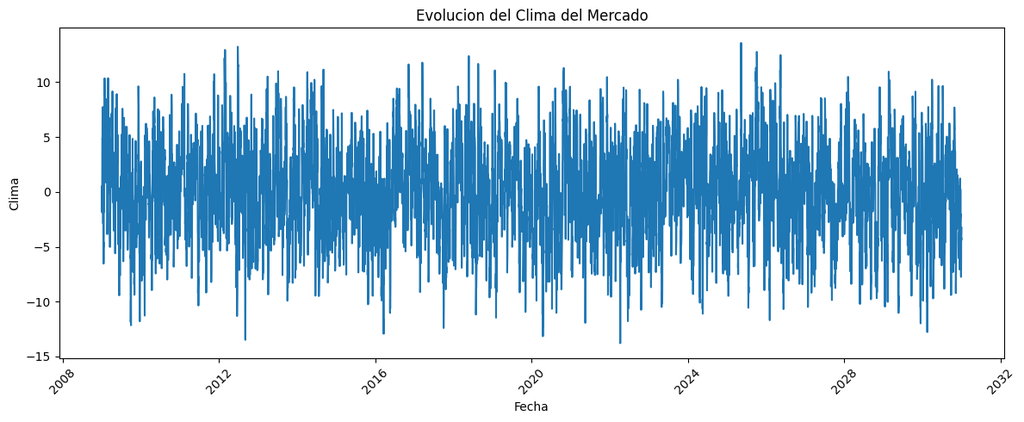

```python
plt.figure(figsize=(12, 5))
sns.lineplot(data=df, x="timestamp", y="clima")
plt.title("Evolucion del Clima del Mercado")
plt.xlabel("Fecha")
plt.ylabel("Clima")
plt.xticks(rotation=45)
plt.tight_layout()
plt.show()
```

Aunque parezca un caos podemos sacar conclusiones sobre esta grafica:

- El clima no se estabiliza nunca, siempre esta oscilando.
- No hay ciclos marcados ni patrones estacionales, pues el clima es una suma diraria de valores independientes.
- Distribuicion centrada en 0, visualmente el clima esta balanceado, pasa tanto por valores negativos como positivos.

Vamos a intentar suavizar la grafica haciendo un suavizado con `rolling window` para ver si podemos sacar algo mas:

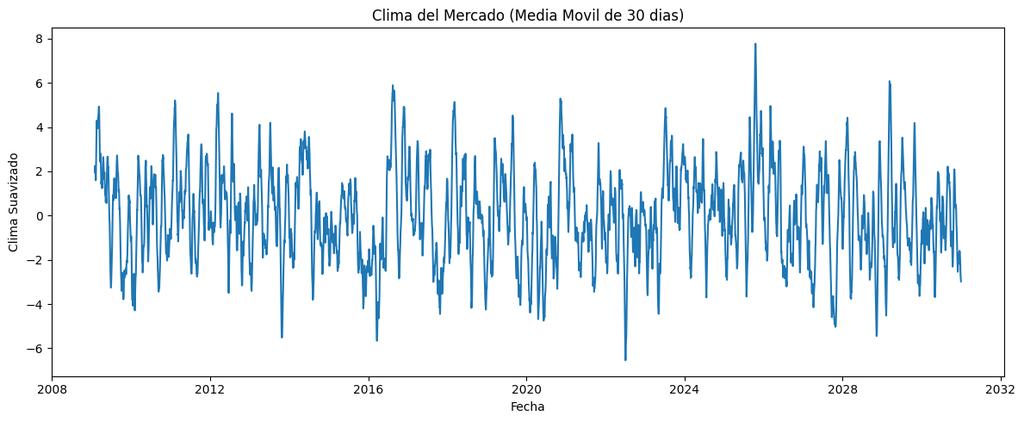

```python
df["clima_rolling"] = df["clima"].rolling(window=30).mean()

plt.figure(figsize=(12, 5))
sns.lineplot(x="timestamp", y="clima_rolling", data=df)
plt.title("Clima del Mercado (Media Movil de 30 dias)")
plt.xlabel("Fecha")
plt.ylabel("Clima Suavizado")
plt.tight_layout()
plt.show()
```

Con el suavizado vemos que:

- Hay ventanas donde el clima se mantiene mayormente por encima o por debajo de 0, probablemente relacionado con las tendencias alcistas y bajistas que implementamos a la simulacion.
- Hay picos extremos, probablemente con muchos factores alineados con el clima.
- Tras los picos vemos como la grafica tiende a estabilizarse o invertirse.

#### Hay correlacion con el precio suavizado?

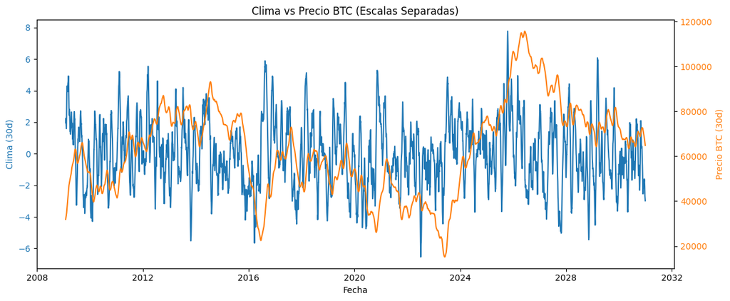

```python
df["precio_rolling"] = df["precio_btc"].rolling(window=30).mean()

fig, ax1 = plt.subplots(figsize=(12, 5))

color_clima = "tab:blue"
ax1.set_xlabel("Fecha")
ax1.set_ylabel("Clima (30d)", color=color_clima)
ax1.plot(df["timestamp"], df["clima_rolling"], color=color_clima, label="Clima (30d)")
ax1.tick_params(axis='y', labelcolor=color_clima)

ax2 = ax1.twinx()
color_precio = "tab:orange"
ax2.set_ylabel("Precio BTC (30d)", color=color_precio)
ax2.plot(df["timestamp"], df["precio_rolling"], color=color_precio, label="Precio BTC (30d)")
ax2.tick_params(axis='y', labelcolor=color_precio)

plt.title("Clima vs Precio BTC (Escalas Separadas)")
fig.tight_layout()
plt.show()
```

El clima tiene a ir por delante del precio:

- Muchos picos del clima ocurren justo antes de cambios relevantes en el precio, lo apreciamos muy bien durante la subida del precio post 2023 o antes de algunas varias correcciones fuertes.
- Cuando el clima mantiene una racha positica suele acompanarle una subida de precio, al igual que cuando es negativo.
- El clima practicamente funciona como un indicador adelantado.

### 3.4. Distribucion Clima del mercado

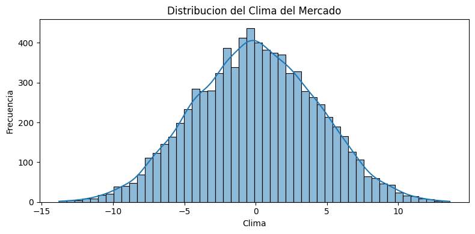

```python
plt.figure(figsize=(8, 4))
sns.histplot(df["clima"], bins=50, kde=True)
plt.title("Distribucion del Clima del Mercado")
plt.xlabel("Clima")
plt.ylabel("Frecuencia")
plt.tight_layout()
plt.show()
```

- Con esta grafica vemos mas claro aun que el clima de mercado oscila el 0 de media.
- Aqune sea muy simetrica, tiene una leve acumulacion en valores negativos, probablemente durante la simulacion el `sentimiento_mercado` haya tenido reacciones mas fuertes a las caidas(FUD mas comun que FOMO)

### 3.5. sentimiento_detectado

#### Evolucion temporal

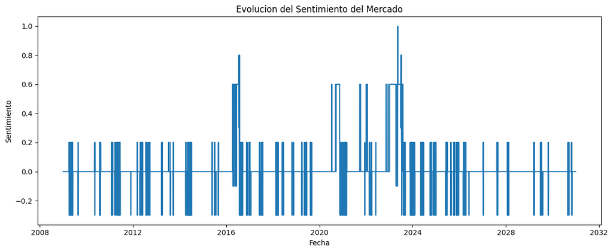

```python
plt.figure(figsize=(12, 5))
sns.lineplot(data=df, x="timestamp", y="sentimiento_detectado")
plt.title("Evolucion del Sentimiento del Mercado")
plt.xlabel("Fecha")
plt.ylabel("Sentimiento")
plt.tight_layout()
plt.show()
```

- El valor de esta columna no es un valor continuo, sino que aparece como reacciones puntuales.
- La mayoria de dias es sentimiento neutro (0), lo que confirma que solo se activa cuando hay eventos concretos que definimos en la simulacion (variaciones de precio, rebotes, euforias)
- Se ven picos puntuales de FOMO que probablemente concidan con subidas en el precio del BTC.
- Tambien hay eventos de FUD (rebote) pero nunca inferiores a -0.3.
- Entre 2016 y 2023 hay una acumulacion de eventos, el mercado seria mas volatil y desencadenaria estas reacciones.

#### Vamos a analizar que ocurre con el precio despues de dias con sentimiento fuerte

```python
# Filtrar dias con sentimiento fuerte
df_sentimiento_fuerte = df[abs(df["sentimiento_detectado"]) > 0.0].copy()

# Cambio del dia siguiente a cada dia con sentimiento
cambio_despues_sentimiento = df.loc[df_sentimiento_fuerte.index + 1, "cambio"]

# Estadisticas del cambio al dia siguiente
print("Cambio del dia siguiente tras sentimiento fuerte:")
print(cambio_despues_sentimiento.describe())

# Direccion del cambio
print("\nFrecuencia de direccion del cambio:")
print(cambio_despues_sentimiento.apply(lambda x: "Sube" if x > 0 else "Baja" if x < 0 else "Neutro").value_counts())
```

```
Cambio del dia siguiente tras sentimiento fuerte:
count    1492.000000
mean      136.987936
std       414.742131
min      -879.000000
25%      -170.500000
50%       192.500000
75%       461.750000
max       916.000000
Name: cambio, dtype: float64

Frecuencia de direccion del cambio:
cambio
Sube    971
Baja    521
Name: count, dtype: int64
```

### 3.6. max_historico

#### Evolucion en el tiempo

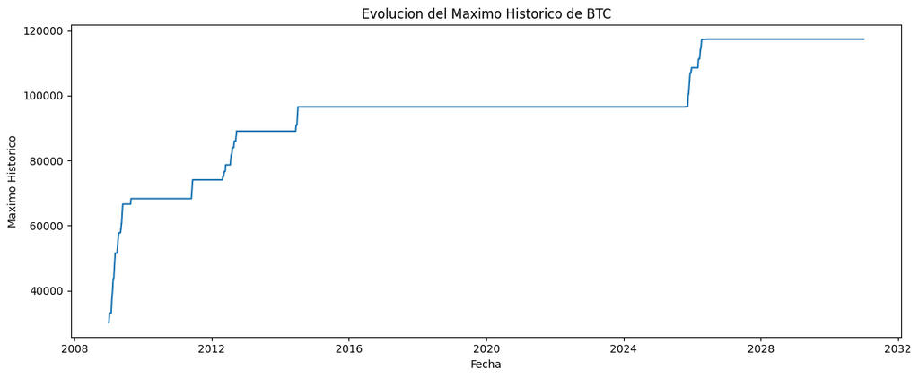

```python
plt.figure(figsize=(12, 5))
sns.lineplot(data=df, x="timestamp", y="max_historico")
plt.title("Evolucion del Maximo Historico de BTC")
plt.xlabel("Fecha")
plt.ylabel("Maximo Historico")
plt.tight_layout()
plt.show()
```

- Vemos como la grafica sigue un patron de: subida -> pausa -> subida -> pausa.
- Vemos fases donde hay muchos escalones seguidos.
- Entre 2015 y 2025 se estanca cerca de los 100.000$ hasta 2026 donde consigue un nuevo maximo y vuelve a quedarse plano.

### 3.7. relacion_con_max

##### Histograma

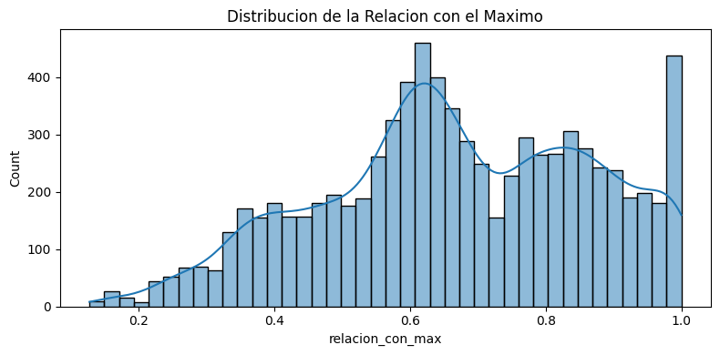

```python
plt.figure(figsize=(8, 4))
sns.histplot(df["relacion_con_max"], bins=40, kde=True)
plt.title("Distribucion de la Relacion con el Maximo")
plt.tight_layout()
plt.show()
```

- Pico fuerte en torno a `0.6`, el precio tiende a mantenerse alrededor del 60% del maximo historico la mayor parte del tiempo.
- Pico fuerte en 1, refleja los dias que el precio iguala al maximo historico.
- Cola densa en el rango `0.3` a `0.5`, nos indica que el precio ha estado lejos del maximo pero sin desplomarse del todo.
- Poca cantidad de dias por debajo de `0.2`, que nos indica que la simulacion no deja caer el precio tan facilmente.

Nuestro mercado simulado pasa la mayor parte del tiempo alejado de su maximo, con picos puntuales, El precio se estabiliza mayoritariamente entre el 50% y 80% del maximo historico.

##### Evolucion temporal

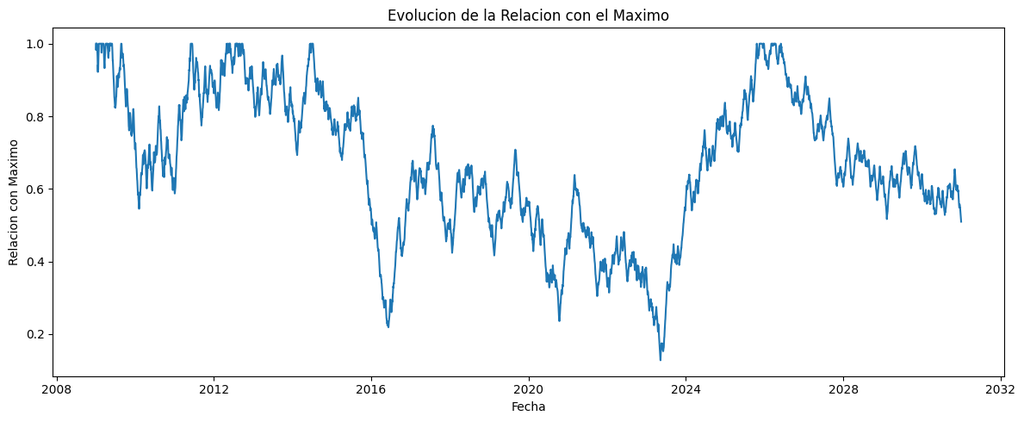

```python
plt.figure(figsize=(12, 5))
sns.lineplot(data=df, x="timestamp", y="relacion_con_max")
plt.title("Evolucion de la Relacion con el Maximo")
plt.xlabel("Fecha")
plt.ylabel("Relacion con Maximo")
plt.tight_layout()
plt.show()
```

### 3.8. Promedio de los factores del clima

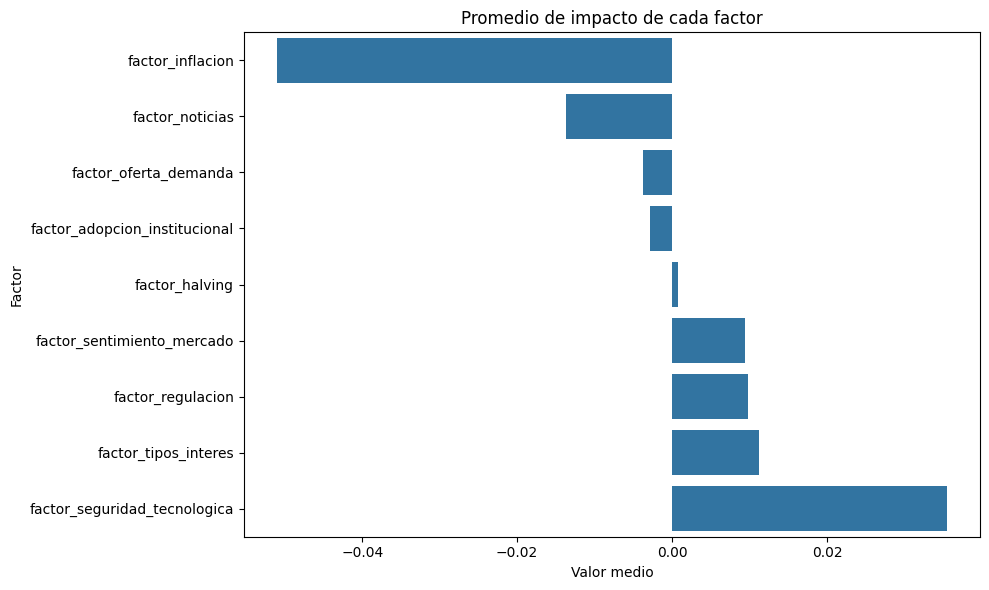

```python
factores = [col for col in df.columns if col.startswith("factor_")]
promedios = df[factores].mean().sort_values()

plt.figure(figsize=(10, 6))
sns.barplot(x=promedios.values, y=promedios.index)
plt.title("Promedio de impacto de cada factor")
plt.xlabel("Valor medio")
plt.ylabel("Factor")
plt.tight_layout()
plt.show()
```

Por como esta construida nuestra simulacion, podemos expresar el significado del grafico con la siguiente "conclusion": El BTC se ha visto impulsado principalmente por la seguridad tecnologica, el interes y la regulacion, por otro lado, la inflacion y las noticias han jugado en contra de nuestra simulacion.

## 4. Escalado de caracteristicas

Para ello con los datos del `csv` vamos a realizar un breve analisis de las columnas a escalar y el tipo de escalado que debemos hacer, para ello hemos seguido la siguiente estrategia:

- StandardScaler:

cambio, clima, sentimiento_detectado, relacion_con_max, max_historico.

- MinMaxScaler:

dias_en_euforia, dias_rebote_fuerte (por ser conteos acotados).

- Sin escalado:

Columnas factor_*, ya que ya están normalizadas entre -1 y 1.

- Variable objetivo: precio_btc se ha mantenido sin transformación, ya que es la variable a predecir.

```python
from sklearn.preprocessing import StandardScaler, MinMaxScaler, OneHotEncoder
import numpy as np

# Copiar el DataFrame original y eliminamos el timestamp y el precio
df_features = df.drop(columns=['timestamp', 'precio_btc'])
```

Ahora realizamos el encoding a cada columna seleccionada en un bucle

```python
# Inicializamos pandas
transformed_features = pd.DataFrame()

# Procesamos cada columna en un bucle
for col in df_features.columns:
    if col in ['cambio', 'clima', 'sentimiento_detectado', 'relacion_con_max']:
        # Escalar con StandardScaler para normalizar distribución
        scaler = StandardScaler()
        transformed_col = scaler.fit_transform(df_features[[col]])
        transformed_features[col] = transformed_col.flatten()
    elif col in ['dias_en_euforia', 'dias_rebote_fuerte']:
        # Escalar con MinMaxScaler por su naturaleza de conteo limitado
        scaler = MinMaxScaler()
        transformed_col = scaler.fit_transform(df_features[[col]])
        transformed_features[col] = transformed_col.flatten()
    elif col.startswith('factor_'):
        # Están todos ya entre -1 y 1, no hace falta escalar
        transformed_features[col] = df_features[col]
    else:
        # Escalado estándar por defecto para las demas columnas
        scaler = StandardScaler()
        transformed_col = scaler.fit_transform(df_features[[col]])
        transformed_features[col] = transformed_col.flatten()
```

Ahora reincorporamos la variable objetivo y la fecha

```python
transformed_features['precio_btc'] = df['precio_btc']
transformed_features['timestamp'] = df['timestamp']

# Mostramos un resumen
transformed_features.head()
```

|  | cambio | clima | tendencia_largo_plazo | sentimiento_detectado | max_historico | relacion_con_max | dias_en_euforia | dias_rebote_fuerte | factor_tipos_interes | factor_inflacion | factor_adopcion_institucional | factor_noticias | factor_regulacion | factor_halving | factor_seguridad_tecnologica | factor_oferta_demanda | factor_sentimiento_mercado | precio_btc | timestamp |
| --- | --- | --- | --- | --- | --- | --- | --- | --- | --- | --- | --- | --- | --- | --- | --- | --- | --- | --- | --- |
| 0 | 0.177252 | 0.119953 | 0.448385 | -0.092656 | -4.205747 | 1.679024 | 0.0 | 0.0 | -1.00 | 0.0 | 0.0 | 0.0 | 0.00 | 0.00 | 0.0 | 0.0 | 1.00 | 30080 | 2009-01-01 |
| 1 | -1.235330 | -0.431117 | 0.448385 | -0.092656 | -4.205747 | 1.590118 | 0.0 | 0.0 | -0.93 | 0.0 | 0.0 | 0.0 | 0.00 | 1.00 | 0.0 | 0.0 | -1.00 | 29552 | 2009-01-02 |
| 2 | 0.999709 | 0.470209 | -0.453210 | -0.092656 | -4.205747 | 1.663364 | 0.0 | 0.0 | 1.00 | 0.0 | 0.0 | 0.0 | 0.00 | 0.93 | 0.0 | 0.0 | -0.93 | 29986 | 2009-01-03 |
| 3 | 1.945302 | 1.138031 | -1.354805 | -0.092656 | -4.158016 | 1.679024 | 0.0 | 0.0 | 0.93 | 0.0 | 0.0 | 0.0 | 1.00 | 0.86 | 0.0 | 0.0 | -0.86 | 30827 | 2009-01-04 |
| 4 | 0.783639 | 1.121686 | 0.448385 | -0.092656 | -4.136227 | 1.679024 | 0.0 | 0.0 | 1.00 | 0.0 | 0.0 | 0.0 | 0.93 | 0.79 | 0.0 | 0.0 | -0.79 | 31168 | 2009-01-05 |

- Codificación

Actualmente no hay columnas categóricas tipo string en el dataset, asi que no es necesario aplicar codifiación

- Conjuntos de entrenamiento y test (20%)

El conjunto de entrenamiento y test lo realizaremos en el proceso de creación de los modelos de ML para mayor comodidad+

Finalmente guardamos el nuevo csv listo para ser usado en modelos de ML.

```python
transformed_features.to_csv("btc_datos_escalados.csv", index=False)
```